```python
from IPython.display import display, HTML
display(HTML("<style>.rendered_html { font-family: Computer Modern; font-size: 15px; }</style>"))
```

# MAT496: Capstone Project

Selim Kalici  
The State University of New York at Oswego  
October 25, 2023

Supervised by Prof. Zheng Hao of the SUNY Oswego Mathematics Department

## 1. Introduction

In this work I present the results of my semester long capstone project at SUNY Oswego supervised by Prof. Zheng Hao. In this project I investigated the equations of motion for free particles in Gaussian Random Fields (GRFs).[<sup>[1]</sup>](https://en.wikipedia.org/wiki/Gaussian_random_field) For the purposes in this work we define a GRF as a vector field $(u,v)$ where both $u$ and $v$ are normally distributed, or

$$ \overline{F} = \langle u, v\rangle \sim \langle \mathcal{N}(\mu_x, \sigma_x), \mathcal{N}(\mu_y, \sigma_y)\rangle. $$

Now, this GRF will work as our force on a particle at each point, so the acceleration of the particle is simply given by $\overline{a} = \overline{F}/m$. Letting the mass of our particle be 1kg for simplicity, we see that the acceleration at each point on our plane is normally distributed with $\overline{a} = \overline{F}$. We consider an otherwise free particle traversing this field with initial position $\langle x_0, y_0\rangle$ and initial velocity $\langle v_{x0}, v_{y0}\rangle$. Since the position along the $x$ and $y$ axes are independent, we will only concern ourselves with the x-axis and work by analogy. The equations of motion and their stochastic counterparts for such a particle are given by:

\begin{align*} & x(t) = x_0 + v_0t + \frac{1}{2}at^2 & x_{n+1} = x_n + v_n\alpha + \frac{1}{2}a_{n}\alpha^2 &\\ & v(t) = v_0 + at & v_{n+1} = v_n + a_n\alpha~~~~~~~~ ~~~~~~~~ \\ \end{align*}

where $\alpha$ is our time step.

## 2. The stochastic process $\{x_n(t)\}$

### 2.1 Expected value of motion in Gaussian random field

We are investigating the equation of projectile motion under the effects of traveling through a random vector field. The equation of projectile motion along a given axis is given by

$$ x = x_0 + v_0t + \frac{1}{2}a_xt^2. $$

The first step is converting this to a stochastic process, and assuming that the acceleration due to the field is normally distributed, we see that

$$ x_{n+1} = x_n + v_n\alpha + \frac{1}{2}\alpha^2a_x, \quad\quad\quad a_x \thicksim\mathcal{N}(\mu_x,\sigma_x); $$

where $\alpha$ is our time step size. First, we find the expected value of the stochastic process distance along the x-axis after $n+1$ steps. Then our goal is to find $\mathbb{E}(x_{n+1})$. First, it is useful to know the expectation of velocity and acceleration, so we compute

\begin{align*} \mathbb{E}(v_{n+1}) &= \mathbb{E}(v_{n}+a_n\alpha) = \mathbb{E}(v_{n}) + \alpha\mathbb{E}(a_n)\\ &=\mathbb{E}(v_{n-1}) + \alpha\mathbb{E}(a_n+a_{n-1})\\ & ~ ~\vdots\\ &= v_0 + \alpha\sum_{m=1}^{n}\mathbb{E}(a_m) = v_0 + \alpha n\mu_x \end{align*}

where the expectation of the acceleration at each time step $\mathbb{E}(a_n) = \mu_x$, since $a_n$ is normally distributed at all times.

\begin{align*} \mathbb{E}(x_{n+1}) &= \mathbb{E}(x_n + v_nt + \frac{1}{2}a_nt^2)\\ &=\mathbb{E}(x_n) + \alpha\mathbb{E}(v_n) + \frac{1}{2}\alpha^2\mathbb{E}(a_n)\\ &=\mathbb{E}(x_{n-1} + \alpha v_{n-1} + \frac{1}{2}\alpha^2a_{n-1})+\alpha\mathbb{E}(v_n)+\frac{1}{2}\alpha^2\mathbb{E}(a_n)\\ &=\mathbb{E}(x_{n-2} + \alpha v_{n-2} + \frac{1}{2}\alpha^2a_{n-2})+\alpha\mathbb{E}(v_{n-1}) + \frac{1}{2}\alpha^2\mathbb{E}(a_{n-1})+\alpha\mathbb{E}(v_n)+\frac{1}{2}\alpha^2\mathbb{E}(a_n)\\ &~ ~\vdots \\ &= x_0 + \alpha\sum_{m=1}^n\mathbb{E}(v_m) + \frac{1}{2}\alpha^2\sum_{m=0}^n\mathbb{E}(a_m)\\ &= x_0 + \alpha n v_0 + \mu_xn\left(\frac{1}{2}\alpha(n+1)-1+\frac{1}{2}\alpha^2\right) \end{align*}

Then we see that for a standard normal distribution with mean $0$, the expected value of the distance traveled is just the initial trajectory, or $x_n = x_0 + v_0n\alpha = x_0 + v_0t$.

### 2.2 Variance of motion in Gaussian random field

Then we seek to compute the variance via the formula

\begin{align*} Var(x_{n+1}) &= \mathbb{E}(x_{n+1}^2) - \mathbb{E}^2(x_{n+1}). & \left( \sum_{n=1}^N a_n \right)^2 = \sum_{n=1}^N a_n^2 + 2 \sum_{j=1}^{N}\sum_{i=1}^{j-1} a_i a_j \end{align*}

As before, it is useful to first find the expectation of the square variance and acceleration, as these results will be helpful in the future. We may first see that the variance of acceleration is $Var(a_n) = \sigma_x$ since it is normally distributed. Then it follows that

\begin{align*} \sigma_x^2 &= Var(a_n) = \mathbb{E}(a_n^2) - \mathbb{E}^2(a_n) = \mathbb{E}(a_n^2) - \mu_x^2\\ & \implies \mathbb{E}(a_n^2) = \sigma_x^2 - \mu_x^2. \end{align*}

This allows us to compute the variance in velocity after n-steps, or $Var(v_n)$.

\begin{align*} Var(v_n) = \mathbb{E}(v_n^2) - \mathbb{E}^2(v_n) = \mathbb{E}(v_n^2) - \left(v_0 + \alpha(n-1)\mu_x\right)^2 \end{align*}

Then,

\begin{align*} \mathbb{E}(x_{n+1}^2) &= \mathbb{E}\left[\left(x_n+v_n\alpha + \frac{1}{2}\alpha^2a_n\right)^2\right] = \mathbb{E}\left[\left(x_0 + \alpha\sum_{m=1}^nv_m + \frac{1}{2}\alpha^2\sum_{m=0}^na_m\right)^2\right]\\ &= \mathbb{E}\left(x_0^2 + \alpha^2\left(\sum_{m=1}^nv_m\right)^2 + \frac{1}{4}\alpha^4\left(\sum_{m=0}^na_m\right)^2 +2\sum a_m\sum v_m + 2x_0\sum a_m +2x_0\sum v_m \right) \end{align*}

### 2.3 $\{x_n(t)\}$ as a Markov Chain

$\hspace{25cm}\blacksquare$

### 2.4 $\{v_n(t)\}$ as a Brownian Motion

$\hspace{25cm}\blacksquare$

## 3. A Simulated Example

### Common Imports

```python
import numpy as np
import matplotlib.pyplot as plt

plt.rcParams['figure.figsize'] = (10, 6)

font = {'family' : 'Arial',
        'size'   : 15}

plt.rc('font', **font)
plt.style.use('bmh')

import seaborn
seaborn.set()
```

### Increment function

```python
def get_next(pos, vel, F, dt, x, y, m=1):
    i, j = closest_coord(pos, x, y)
    ind = (i, j)
    # x = x_0 + v_0t + .5at^2, a~(1/m)N(mu, std)
    x_1 = pos[0] + vel[0]*dt + 0.5*(1/m)*F[ind][0]*dt**2
    y_1 = pos[1] + vel[1]*dt + 0.5*(1/m)*F[ind][1]*dt**2
    # v = v_0 + at
    xdot_1 = vel[0] + (1/m)*F[ind][0]*dt
    ydot_1 = vel[1] + (1/m)*F[ind][1]*dt

    return (x_1, y_1), (xdot_1, ydot_1)

def closest_coord(pos, x, y):
    min_val = 100
    coord = (0,0)
    x_0, y_0 = pos

    for i in range(len(x)):

        for j in range(len(y)):

            dist = (x_0 - x[i,j].flatten())**2 + (y_0 - y[i,j].flatten())**2

            if min_val > dist:
                min_val = dist
                coord = (i,j)

    return coord
```

### Simulation

[output not shown]

[output cut: 445 more lines]

[output not shown]

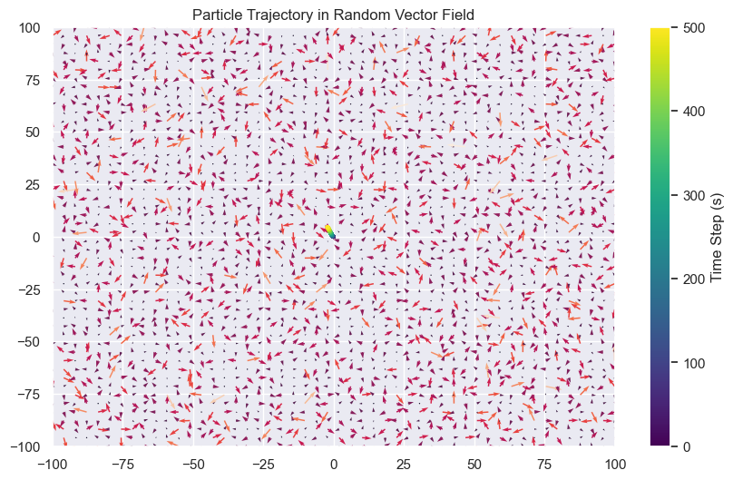

```python
num = 50
step_count = 500
x, y = np.meshgrid(np.linspace(-100, 100, num),
                   np.linspace(-100, 100, num),
                  indexing='ij')

mu = 0
sigma_0 = 2
sigma_1 = 2
u = np.random.normal(mu, sigma_0, num**2)
v = np.random.normal(mu, sigma_1, num**2)

F = np.array([
    np.array([(u[i], v[j]) for i in range(num**2)]) for j in range(num**2)
    ])

M = np.hypot(u, v)
plt.quiver(x, y, u, v, M)
plt.title('Particle Trajectory in Random Vector Field')
plt.xlim(-100, 100)
plt.ylim(-100, 100)

dt = 0.1
position = [(0,0)]
velocity = [(0,0)]
for i in range(step_count):
    p, v = get_next(position[i-1], velocity[i-1], F, dt, x, y)
    position.append(p)
    velocity.append(v)


x_coord = [position[i][0] for i in range(len(position))]
y_coord = [position[i][1] for i in range(len(position))]
plt.scatter(x_coord, y_coord,
            c=list(range(step_count+1)), cmap='viridis', s=5)
plt.colorbar(label='Time Step (s)')
```

## 4. Monte Carlo Estimates of Mean and Variance

```python
# Progress bars to monitor simulation
from tqdm.notebook import trange, tqdm
```

```python
num = 50 # number of vectors along each axis on our grid
step_count = 100 # number of steps to take for each iteration
total_count = 1000 # total number of iterations
dt = 0.1 # step size

x, y = np.meshgrid(np.linspace(-100, 100, num),
                   np.linspace(-100, 100, num),
                  indexing='ij')

mu = 0
sigma_0 = 2 # sd along x axis
sigma_1 = 2 # sd along y axis

final_positions = [] # final position of each iteration
final_velocities = [] # final velocity of each iteration

positions_history = [] # all simulated positions
velocities_history = [] # all simulated velocities

for _ in trange(total_count):
    # defining the x and y components of the vector field
    u = np.random.normal(mu, sigma_0, num**2)
    v = np.random.normal(mu, sigma_1, num**2)

    # putting the vectors in a 2d array
    F = np.array([
    np.array([(u[i], v[j]) for i in range(num**2)]) for j in range(num**2)
    ])
    position = [(0,0)]
    velocity = [(0,0)]
    # advancing the simulation for N steps (N = step_count)
    for i in range(step_count):
        p, v = get_next(position[i-1], velocity[i-1], F, dt, x, y)
        position.append(p)
        velocity.append(v)
    final_positions.append(p)
    final_velocities.append(v)
    positions_history.append(position)
    velocities_history.append(velocity)
```

```python
final_X = np.array([__pos[0] for __pos in final_positions])
final_Y = np.array([__pos[1] for __pos in final_positions])
final_Vx = np.array([__vel[0] for __vel in final_velocities])
final_Vy = np.array([__vel[1] for __vel in final_velocities])
```

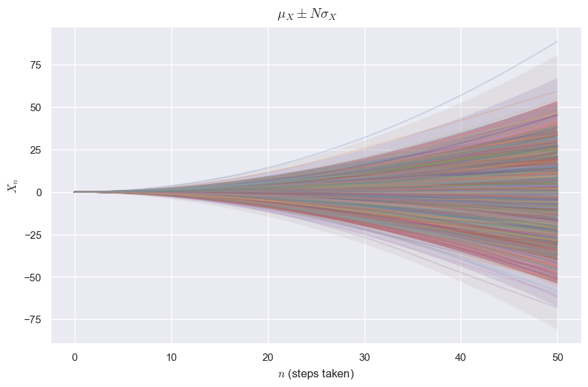

```python
n = np.array(list(range(51)))
sd =np.sqrt(0.25*((0.1)**4)*((n+1)**2)*((n+3)**2))
plt.fill_between(n, sd, -sd, alpha=1)
plt.fill_between(n, 2*sd, -2*sd, alpha=.7)
plt.fill_between(n, 3*sd, -3*sd, alpha=.6)
plt.fill_between(n, 4*sd, -4*sd, alpha=.5)
plt.fill_between(n, 5*sd, -5*sd, alpha=.2)
plt.fill_between(n, 6*sd, -6*sd, alpha=.1)
for path in positions_history[:]:
    path_x = [_[0] for _ in path[::2]]
    plt.plot(range(len(path_x)), path_x, alpha=0.2)
plt.suptitle('$\mu_X \pm N\sigma_X$', y=0.93)
plt.xlabel('$n$ (steps taken)')
plt.ylabel('$X_n$')
```

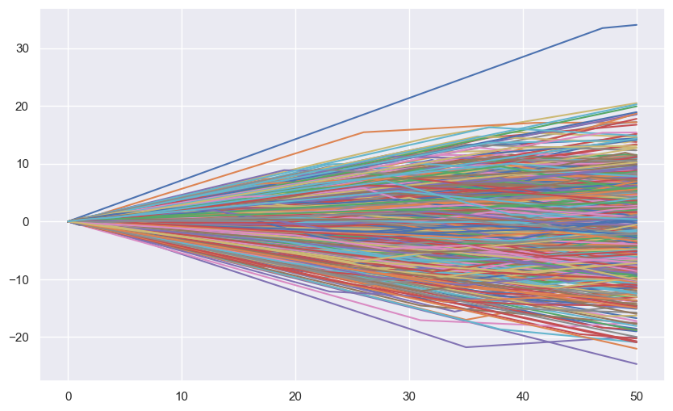

```python
for path in velocities_history:
    path_x = [_[0] for _ in path[::2]]
    plt.plot(range(len(path_x)), path_x)
```

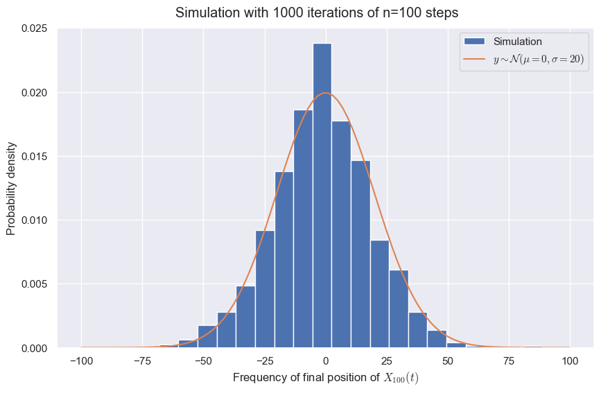

```python
import scipy.stats as stats

plt.hist(final_X, density=True, bins=20, label='Simulation')
mu = 0
sigma= 20
norm = np.linspace(mu - 5*sigma, mu + 5*sigma, 100)
plt.plot(norm, stats.norm.pdf(norm, mu, sigma), label='$y\sim\mathcal{N}(\mu=0,\sigma=20)$')
plt.suptitle(f"Simulation with {total_count} iterations of n={step_count} steps", y=.93)
plt.xlabel("Frequency of final position of $X_{100}(t)$")
plt.ylabel("Probability density")
plt.legend()
plt.show()
```

## 5. The Distribution of $X_n$

## 6. The Expected Deviation from the Intended Path

## 7. Conclusion

## Bibliography

[[Ross24]](https://www.amazon.com/Introduction-Probability-Models-Sheldon-Ross/dp/0124079482) Ross, S. M. (2024). *Introduction to probability models*. London, United Kingdom: Academic Press, an imprint of Elsevier.